# Project 2: Data Mining, Classification, Prediction

SDS322E

# Mining, Classification, Prediction

## Yuxuan Zhuang, yz24574

### Introduction

##### The data used in this project was “police_killings” in the R Package “fivethirtyeight.”

```r
library(tidyverse)
library(fivethirtyeight)
colnames(police_killings)
```

```
##  [1] "name"                 "age"                  "gender"
##  [4] "raceethnicity"        "month"                "day"
##  [7] "year"                 "streetaddress"        "city"
## [10] "state"                "latitude"             "longitude"
## [13] "state_fp"             "county_fp"            "tract_ce"
## [16] "geo_id"               "county_id"            "namelsad"
## [19] "lawenforcementagency" "cause"                "armed"
## [22] "pop"                  "share_white"          "share_black"
## [25] "share_hispanic"       "p_income"             "h_income"
## [28] "county_income"        "comp_income"          "county_bucket"
## [31] "nat_bucket"           "pov"                  "urate"
## [34] "college"
```

```r
head(police_killings)
```

```
## # A tibble: 6 × 34
##   name     age gender raceethnicity  month   day  year streetaddress city  state
##   <chr>  <int> <chr>  <chr>          <chr> <int> <int> <chr>         <chr> <chr>
## 1 A'don…    16 Male   Black          Febr…    23  2015 Clearview Ln  Mill… AL
## 2 Aaron…    27 Male   White          April     2  2015 300 block Ir… Pine… LA
## 3 Aaron…    26 Male   White          March    14  2015 22nd Ave and… Keno… WI
## 4 Aaron…    25 Male   Hispanic/Lati… March    11  2015 3000 Seminol… Sout… CA
## 5 Adam …    29 Male   White          March    19  2015 364 Hiwood A… Munr… OH
## 6 Adam …    29 Male   White          March     7  2015 18th St and … Phoe… AZ
## # … with 24 more variables: latitude <dbl>, longitude <dbl>, state_fp <int>,
## #   county_fp <int>, tract_ce <int>, geo_id <dbl>, county_id <int>,
## #   namelsad <chr>, lawenforcementagency <chr>, cause <chr>, armed <chr>,
## #   pop <int>, share_white <dbl>, share_black <dbl>, share_hispanic <dbl>,
## #   p_income <int>, h_income <int>, county_income <int>, comp_income <dbl>,
## #   county_bucket <int>, nat_bucket <int>, pov <dbl>, urate <dbl>,
## #   college <dbl>
```

```r
polik <- police_killings %>% na.omit()

NE <- c("CT", "ME", "MA", "NH", "RI", "VT", "NJ", "NY", "PA")
NE.ref <- c(NE)

MW <- c("IN", "IL", "MI", "OH", "WI", "IA", "KS", "MN", "MO",
    "NE", "ND", "SD")
MW.ref <- c(MW)

S <- c("DE", "DC", "FL", "GA", "MD", "NC", "SC", "VA", "WV",
    "AL", "KY", "MS", "TN", "AR", "LA", "OK", "TX")
S.ref <- c(S)

W <- c("AZ", "CO", "ID", "NM", "MT", "UT", "NV", "WY", "AK",
    "CA", "HI", "OR", "WA")
W.ref <- c(W)

region.list <- list(Northeast = NE.ref, Midwest = MW.ref, South = S.ref,
    West = W.ref)
polik$state_region <- sapply(polik$state, function(x) names(region.list)[grep(x,
    region.list)])
head(polik)
```

```
## # A tibble: 6 × 35
##   name     age gender raceethnicity  month   day  year streetaddress city  state
##   <chr>  <int> <chr>  <chr>          <chr> <int> <int> <chr>         <chr> <chr>
## 1 A'don…    16 Male   Black          Febr…    23  2015 Clearview Ln  Mill… AL
## 2 Aaron…    27 Male   White          April     2  2015 300 block Ir… Pine… LA
## 3 Aaron…    26 Male   White          March    14  2015 22nd Ave and… Keno… WI
## 4 Aaron…    25 Male   Hispanic/Lati… March    11  2015 3000 Seminol… Sout… CA
## 5 Adam …    29 Male   White          March    19  2015 364 Hiwood A… Munr… OH
## 6 Adam …    29 Male   White          March     7  2015 18th St and … Phoe… AZ
## # … with 25 more variables: latitude <dbl>, longitude <dbl>, state_fp <int>,
## #   county_fp <int>, tract_ce <int>, geo_id <dbl>, county_id <int>,
## #   namelsad <chr>, lawenforcementagency <chr>, cause <chr>, armed <chr>,
## #   pop <int>, share_white <dbl>, share_black <dbl>, share_hispanic <dbl>,
## #   p_income <int>, h_income <int>, county_income <int>, comp_income <dbl>,
## #   county_bucket <int>, nat_bucket <int>, pov <dbl>, urate <dbl>,
## #   college <dbl>, state_region <chr>
```

##### The dataset “police_killings” is the raw data behind the article “Where Police Have Killed Americans In 2015” published in 2015. This is the link of that article: https://fivethirtyeight.com/features/where-police-have-killed-americans-in-2015/. In the dataset, there are 34 variables with 467 rows representing people who died from interactions with plolice in the year of 2015. 410 observations in total were used in the analyses below.

```
‘gender’：Gender of deceased
‘raceethnicity’：Race/ethnicity of deceased
‘state’： State where incident occurred. This variable was transformed into a category variable with 4 levels, Northeast, Midwest, South, and West.
'armed': How/whether deceased was armed. This variable was later transformed into a binary variable, 1=armed, 0=unarmed.
'share_white': Share of pop that is non-Hispanic white
'share_black': Share of pop that is black (alone, not in combination)
'share_hispanic': Share of pop that is Hispanic/Latino (any race)
'p_income': Tract-level median personal income
'h_income': Tract-level median household income
'county_income': County-level median household income
'comp_income': 'h_income' / 'county_income'
'pov': Tract-level poverty rate (official)
'urate': Tract-level unemployment rate
'college': Share of 25+ pop with BA or higher
```

### Cluster Analysis

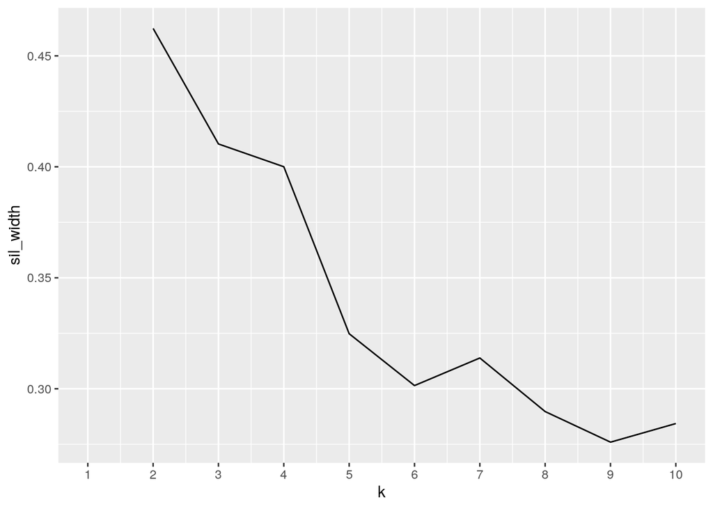

```r
library(cluster)
library(ggplot2)
set.seed(332)
clust_dat <- polik %>% select(share_white, share_black, share_hispanic,
    p_income, h_income, county_income, comp_income, pov, urate,
    college)
sil_width <- vector()
for (i in 2:10) {
    kms <- kmeans(clust_dat, centers = i)
    sil <- silhouette(kms$cluster, dist(clust_dat))
    sil_width[i] <- mean(sil[, 3])
}
ggplot() + geom_line(aes(x = 1:10, y = sil_width)) + scale_x_continuous(name = "k",
    breaks = 1:10)  #suggests 2 clusters
```

```r
pam1 <- clust_dat %>% scale %>% pam(k = 2)
pam1
```

```
## Medoids:
##       ID share_white share_black share_hispanic   p_income   h_income
## [1,] 198   0.7311485  -0.6819573     -0.1398950  0.4427145  0.3169682
## [2,] 306  -0.8146645   0.2254166      0.7374195 -0.3504715 -0.3885359
##      county_income comp_income        pov      urate    college
## [1,]    -0.2901501   0.5654653 -0.7261041 -0.3775237  0.3254297
## [2,]     0.5798295  -0.7340308  0.1852079  0.7611673 -0.6785695
## Clustering vector:
##   [1] 1 2 1 2 1 2 1 2 2 2 1 1 1 1 2 2 2 1 1 2 1 2 2 1 1 1 2 1 2 1 2 2 1 1 2 1 1
##  [38] 2 2 1 1 2 1 2 2 2 2 2 2 1 1 2 1 1 1 1 1 2 1 1 1 1 1 2 2 1 2 2 2 2 2 1 1 1
##  [75] 2 1 1 1 1 2 1 1 2 2 2 2 1 2 1 2 2 1 2 2 2 2 1 1 1 2
##  [ reached getOption("max.print") -- omitted 310 entries ]
## Objective function:
##    build     swap
## 2.678825 2.551228
##
## Available components:
##  [1] "medoids"    "id.med"     "clustering" "objective"  "isolation"
##  [6] "clusinfo"   "silinfo"    "diss"       "call"       "data"
```

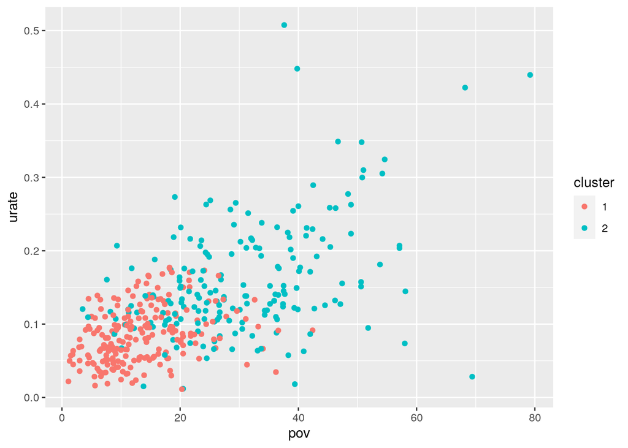

```r
pamclust <- clust_dat %>% mutate(cluster = as.factor(pam1$clustering))
pamclust %>% ggplot(aes(pov, urate, color = cluster)) + geom_point()
```

```r
pamclust %>% group_by(cluster) %>% summarize_if(is.numeric, mean,
    na.rm = T)
```

```
## # A tibble: 2 × 11
##   cluster share_white share_black share_hispanic p_income h_income county_income
##   <fct>         <dbl>       <dbl>          <dbl>    <dbl>    <dbl>         <dbl>
## 1 1              70.6        8.19           12.5   28851.   56837.        52967.
## 2 2              27.0       30.3            34.8   18956.   34176.        53221
## # … with 4 more variables: comp_income <dbl>, pov <dbl>, urate <dbl>,
## #   college <dbl>
```

```r
polik %>% slice(pam1$id.med)
```

```
## # A tibble: 2 × 35
##   name      age gender raceethnicity month   day  year streetaddress city  state
##   <chr>   <int> <chr>  <chr>         <chr> <int> <int> <chr>         <chr> <chr>
## 1 Jason …    29 Male   Black         March    30  2015 3700 Beyer P… Mode… CA
## 2 Naesch…    37 Male   Black         March     6  2015 16200 E 12th… Auro… CO
## # … with 25 more variables: latitude <dbl>, longitude <dbl>, state_fp <int>,
## #   county_fp <int>, tract_ce <int>, geo_id <dbl>, county_id <int>,
## #   namelsad <chr>, lawenforcementagency <chr>, cause <chr>, armed <chr>,
## #   pop <int>, share_white <dbl>, share_black <dbl>, share_hispanic <dbl>,
## #   p_income <int>, h_income <int>, county_income <int>, comp_income <dbl>,
## #   county_bucket <int>, nat_bucket <int>, pov <dbl>, urate <dbl>,
## #   college <dbl>, state_region <chr>
```

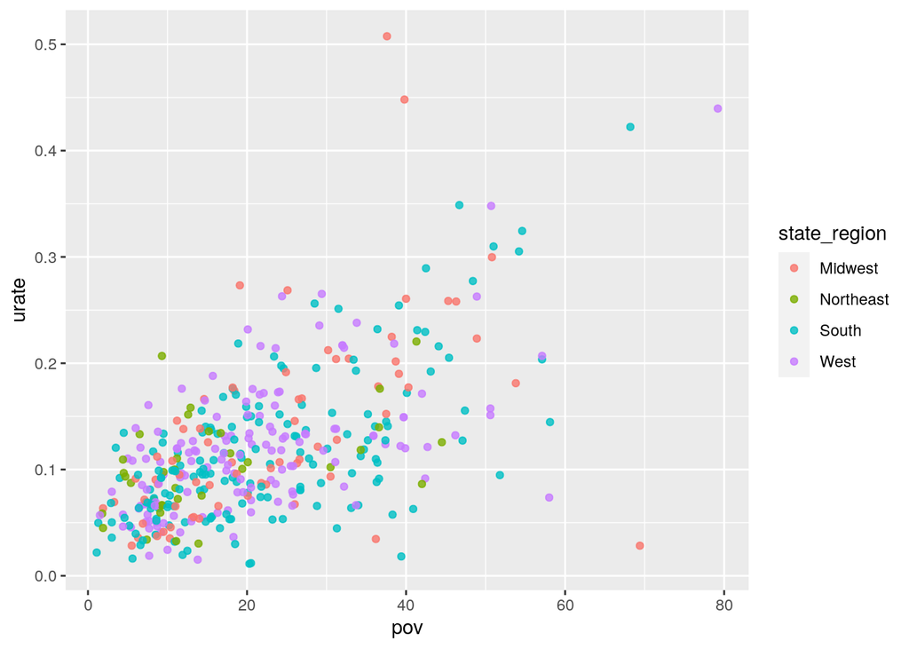

```r
polik %>% ggplot(aes(pov, urate, color = state_region)) + geom_point(alpha = 0.8)
```

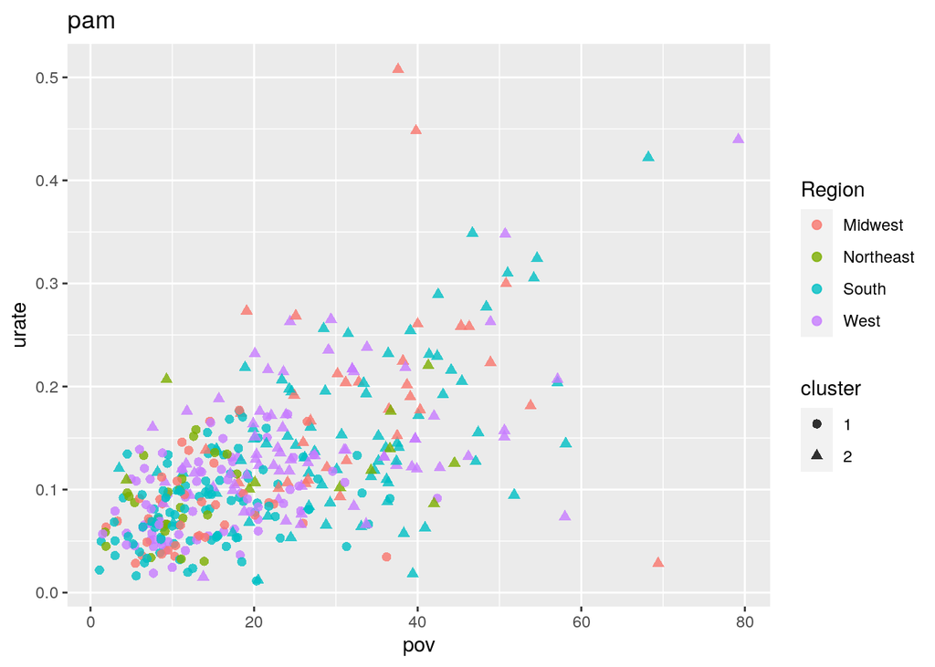

```r
pamclust %>% mutate(Region = polik$state_region) %>% ggplot(aes(pov,
    urate, color = Region, shape = cluster)) + geom_point(size = 2,
    alpha = 0.8) + ggtitle("pam")
```

No significant difference among regions was found.

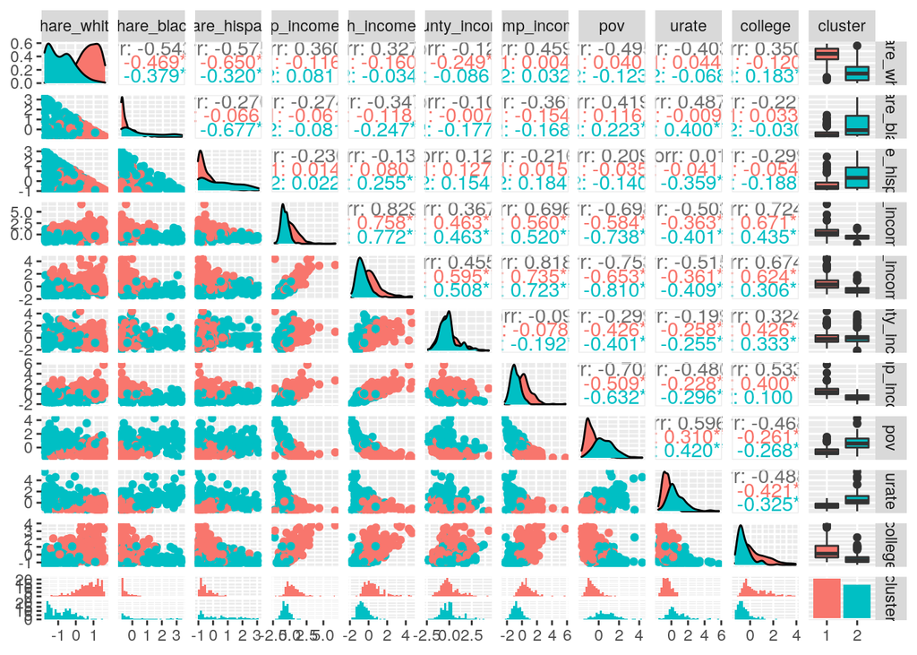

```r
final <- polik %>% select(share_white, share_black, share_hispanic,
    p_income, h_income, county_income, comp_income, pov, urate,
    college) %>% scale %>% as.data.frame
final <- final %>% mutate(cluster = as.factor(pam1$clustering))
library(GGally)
ggpairs(final, aes(color = cluster))
```

```r
pam1$silinfo$avg.width  #average silhouette width=.251
```

```
## [1] 0.2512503
```

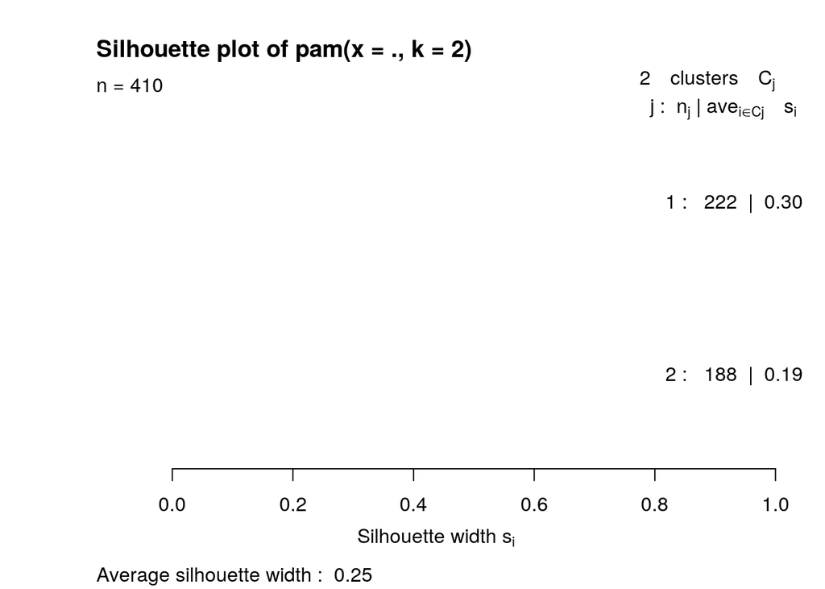

```r
plot(pam1, which = 2)
```

10 variables were used to perform PAM clustering. Sihouette width suggested 2 clusters.

The average silhouette width = .251, which indicates the structure is weak and could be artificial. This might be caused by using too many numeric variables, which interfere with each other.

The variable that distinguished these two clusters the most was share_white (share of pop that is non-Hispanic white). The variable that distinguished these two clusters the least was county_income (county-level median household income).

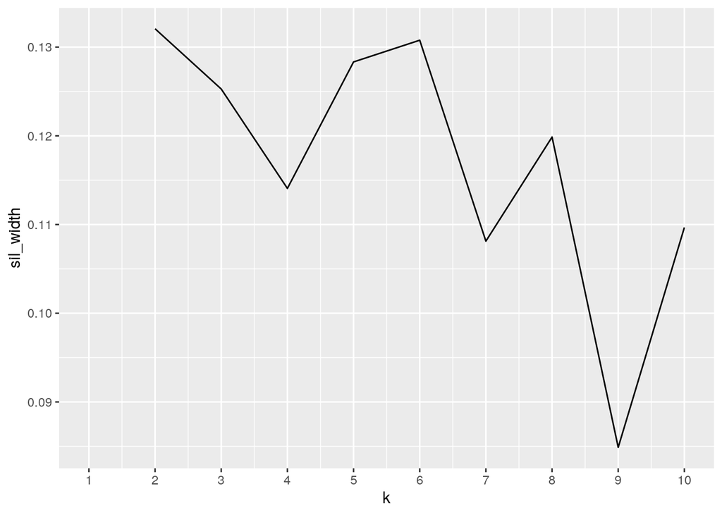

```r
library(cluster)
dat2 <- polik %>% mutate_if(is.character, as.factor) %>% column_to_rownames("name") %>%
    select(-namelsad, -lawenforcementagency, -streetaddress,
        -month)

gower1 <- daisy(dat2, metric = "gower")

sil_width <- vector()
for (i in 2:10) {
    pam_fit <- pam(gower1, diss = TRUE, k = i)
    sil_width[i] <- pam_fit$silinfo$avg.width
}
ggplot() + geom_line(aes(x = 1:10, y = sil_width)) + scale_x_continuous(name = "k",
    breaks = 1:10)  #2 is the best
```

```r
pam3 <- pam(gower1, k = 2, diss = T)
pam3
```

[output not shown]

[output cut: 58 more lines]

```
##                          1                          1
##              Darrell Brown            Darrin Langford
##                          1                          1
##                Daryl Myler               David Cuevas
##                          2                          1
##               David Gaines              David Gandara
##                          2                          1
##  [ reached getOption("max.print") -- omitted 310 entries ]
## Objective function:
##     build      swap
## 0.2280201 0.2280201
##
## Available components:
## [1] "medoids"    "id.med"     "clustering" "objective"  "isolation"
## [6] "clusinfo"   "silinfo"    "diss"       "call"
```

```r
gower1 %>% as.matrix %>% as.data.frame %>% rownames_to_column %>%
    pivot_longer(-1, values_to = "distance") %>% filter(rowname !=
    name) %>% filter(distance %in% c(min(distance), max(distance))) %>%
    distinct(distance, .keep_all = T)
```

```
## # A tibble: 2 × 3
##   rowname      name            distance
##   <chr>        <chr>              <dbl>
## 1 David Garcia Natasha McKenna   0.604
## 2 Eric Harris  Rodney Walker     0.0254
```

According to the gower dissimilarities, David Garcia and Natasha McKenna’s case information (e.g. gender, race-ethnicity, state where incident occurred, cause of death, and how/whether deceased was armed) was different from each other the most. Eric Harris and Rodney Walker’s case information were the most similar.

### Dimensionality Reduction with PCA

```r
polik_nums <- polik %>% select(share_white, share_black, share_hispanic,
    p_income, h_income, county_income, comp_income, pov, urate,
    college) %>% scale
rownames(polik_nums) <- polik$Name
pca1 <- princomp(polik_nums)
summary(pca1, loadings = T)  #first 4 explains 85%
```

```
## Importance of components:
##                           Comp.1    Comp.2    Comp.3     Comp.4     Comp.5
## Standard deviation     2.2040825 1.2493553 1.1424554 0.89722485 0.72934537
## Proportion of Variance 0.4869858 0.1564705 0.1308396 0.08069807 0.05332453
## Cumulative Proportion  0.4869858 0.6434562 0.7742958 0.85499388 0.90831841
##                            Comp.6     Comp.7     Comp.8      Comp.9     Comp.10
## Standard deviation     0.68841791 0.44307873 0.41267918 0.236206822 0.135070542
## Proportion of Variance 0.04750779 0.01967988 0.01707205 0.005593008 0.001828866
## Cumulative Proportion  0.95582620 0.97550608 0.99257813 0.998171134 1.000000000
##
## Loadings:
##                Comp.1 Comp.2 Comp.3 Comp.4 Comp.5 Comp.6 Comp.7 Comp.8 Comp.9
## share_white     0.277  0.487  0.246  0.405  0.139  0.135         0.111  0.641
## share_black    -0.235        -0.667 -0.229 -0.101 -0.384                0.528
## share_hispanic -0.128 -0.609  0.428 -0.296         0.118 -0.127         0.546
## p_income        0.394        -0.224 -0.126         0.140 -0.746  0.439
## h_income        0.407 -0.177 -0.154 -0.200  0.210         0.437  0.210
## county_income   0.144 -0.556 -0.301  0.555  0.252         0.209  0.106
## comp_income     0.373  0.143        -0.557  0.117         0.331
## pov            -0.388                      -0.403  0.444  0.264  0.642
## urate          -0.321        -0.260 -0.126  0.587  0.628 -0.107 -0.232
## college         0.344        -0.274        -0.583  0.445        -0.507
##                Comp.10
## share_white
## share_black
## share_hispanic
## p_income
## h_income       -0.668
## county_income   0.389
## comp_income     0.628
## pov
## urate
## college
```

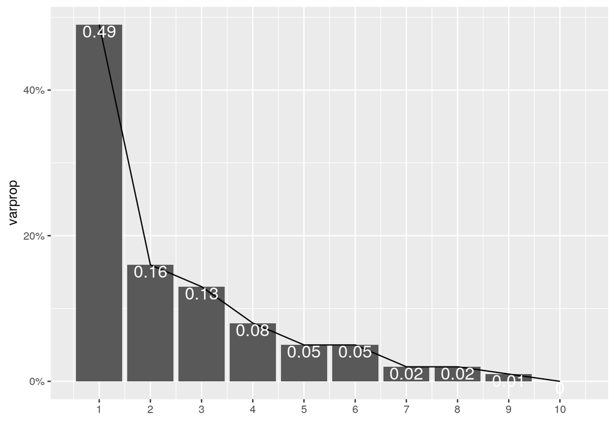

```r
eigval <- pca1$sdev^2
varprop = round(eigval/sum(eigval), 2)
ggplot() + geom_bar(aes(y = varprop, x = 1:10), stat = "identity") +
    xlab("") + geom_path(aes(y = varprop, x = 1:10)) + geom_text(aes(x = 1:10,
    y = varprop, label = round(varprop, 2)), vjust = 1, col = "white",
    size = 5) + scale_y_continuous(breaks = seq(0, 0.6, 0.2),
    labels = scales::percent) + scale_x_continuous(breaks = 1:10)
```

```r
round(cumsum(eigval)/sum(eigval), 3)
```

```
##  Comp.1  Comp.2  Comp.3  Comp.4  Comp.5  Comp.6  Comp.7  Comp.8  Comp.9 Comp.10
##   0.487   0.643   0.774   0.855   0.908   0.956   0.976   0.993   0.998   1.000
```

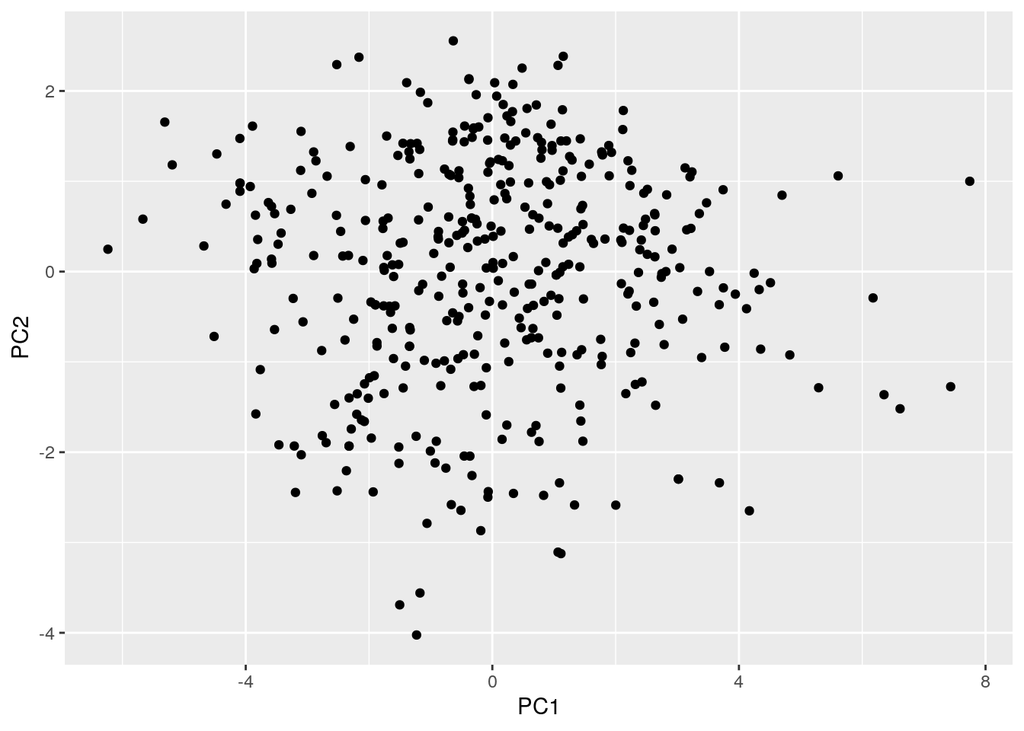

```r
pkdf <- data.frame(PC1 = pca1$scores[, 1], PC2 = pca1$scores[,
    2])
ggplot(pkdf, aes(PC1, PC2)) + geom_point()
```

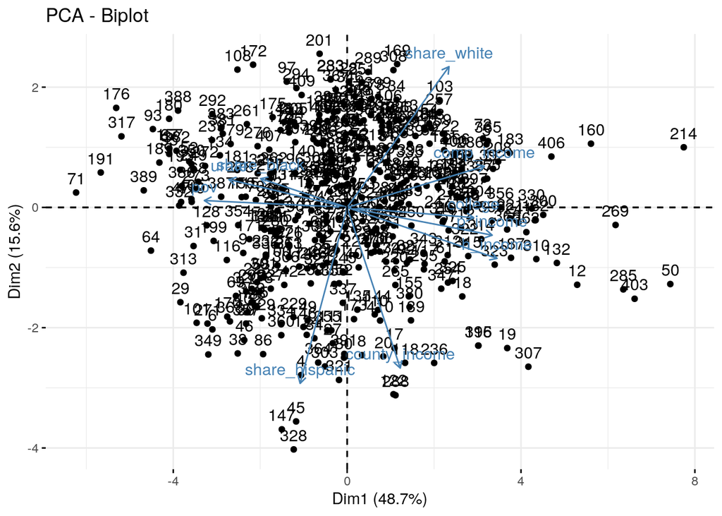

```r
library(factoextra)
fviz_pca_biplot(pca1)  #the number stands for the case number
```

PC1, PC2, and PC3 account for 77.4% of all of the variance. PC1, PC2, PC3, and PC4 account for 85.5% of all of the variance. I picked 4 PCs.

PC2 explained 15.6% of the total variance. PC2 (uncorrelated with PC1) is a share_white (share of pop that is non-Hispanic white) and share_hispanic (share of pop that is Hispanic/Latino (any race)) axis. Higher share of non-Hispanic white population means lower share of Hispanic/Latino (any race) population. High score on PC2 means high share of non-Hispanic white population, high ‘comp_income’, low ‘share_hispanic’, low ‘h_income’, and low ‘county income’.

### Linear Classifier (Linear Regression)

```r
polik %>% select(armed) %>% table()
```

```
## .
##           Disputed            Firearm              Knife                 No
##                  1                206                 64                 91
## Non-lethal firearm              Other            Vehicle
##                  8                 22                 18
```

```r
polik$ar <- polik$armed
polik$ar <- polik$ar %>% recode(Firearm = 1, Disputed = 1, Knife = 1,
    `Non-lethal firearm` = 1, Other = 1, Vehicle = 1, No = 0)
fit <- lm(ar ~ urate, data = polik, family = "binomial")  #using linear regression for classification
score <- predict(fit)
score %>% round(3)
```

```
##     1     2     3     4     5     6     7     8     9    10    11    12    13
## 0.773 0.765 0.789 0.779 0.765 0.767 0.781 0.772 0.783 0.791 0.759 0.763 0.763
##    14    15    16    17    18    19    20    21    22    23    24    25    26
## 0.766 0.771 0.804 0.753 0.759 0.765 0.777 0.758 0.792 0.812 0.752 0.781 0.770
##    27    28    29    30    31    32    33    34    35    36    37    38    39
## 0.773 0.792 0.784 0.791 0.802 0.802 0.765 0.782 0.799 0.790 0.776 0.779 0.781
##    40    41    42    43    44    45    46    47    48    49    50    51    52
## 0.763 0.785 0.784 0.777 0.775 0.779 0.776 0.805 0.796 0.768 0.754 0.769 0.798
##    53    54    55    56    57    58    59    60    61    62    63    64    65
## 0.761 0.772 0.780 0.786 0.760 0.801 0.760 0.776 0.763 0.762 0.769 0.833 0.774
##    66    67    68    69    70    71    72    73    74    75    76    77    78
## 0.773 0.811 0.787 0.765 0.801 0.854 0.772 0.757 0.772 0.783 0.762 0.774 0.782
##    79    80    81    82    83    84    85    86    87    88    89    90    91
## 0.767 0.766 0.758 0.783 0.785 0.788 0.775 0.784 0.769 0.781 0.780 0.772 0.794
##    92    93    94    95    96    97    98    99   100
## 0.773 0.823 0.798 0.833 0.789 0.771 0.787 0.769 0.781
##  [ reached getOption("max.print") -- omitted 310 entries ]
```

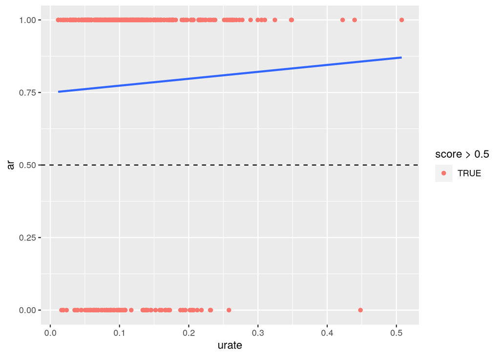

```r
polik %>% mutate(score = score) %>% ggplot(aes(urate, ar)) +
    geom_point(aes(color = score > 0.5)) + geom_smooth(method = "lm",
    se = F) + geom_hline(yintercept = 0.5, lty = 2)
```

```r
class_diag(score, truth = polik$ar, positive = 1)  #AUC=.53, low accuracy
```

```
##           acc sens spec   ppv     f1  ba    auc
## Metrics 0.778    1    0 0.778 0.8752 0.5 0.5252
```

```r
set.seed(322)
k = 10

data <- polik[sample(nrow(polik)), ]
folds <- cut(seq(1:nrow(data)), breaks = k, labels = F)

diags <- NULL
for (i in 1:k) {
    train <- data[folds != i, ]
    test <- data[folds == i, ]
    truth <- test$ar
    fit <- lm(ar ~ pov, data = train, family = "binomial")
    probs <- predict(fit, newdata = test, type = "response")
    diags <- rbind(diags, class_diag(probs, truth, positive = 1))
}
summarize_all(diags, mean)
```

```
##       acc sens spec     ppv      f1  ba     auc
## 1 0.77806    1    0 0.77806 0.87347 0.5 0.55312
```

I used K-fold CV for cross validation. AUC=.55 indicated the classfication did not work well in new data, but it was slightly higher than the training data. There was no overfitting.

### Non-Parametric Classifier (k-nearest-neighbors)

```r
library(caret)
knn_fit <- knn3(factor(ar == 1, levels = c("TRUE", "FALSE")) ~
    pov, data = polik, k = 5)
y_hat_knn <- predict(knn_fit, polik) %>% round(2)
y_hat_knn
```

```
##        TRUE FALSE
##   [1,] 0.40  0.60
##   [2,] 0.80  0.20
##   [3,] 0.44  0.56
##   [4,] 1.00  0.00
##   [5,] 0.60  0.40
##   [6,] 0.60  0.40
##   [7,] 1.00  0.00
##   [8,] 0.67  0.33
##   [9,] 0.83  0.17
##  [10,] 1.00  0.00
##  [11,] 0.75  0.25
##  [12,] 0.80  0.20
##  [13,] 0.71  0.29
##  [14,] 0.83  0.17
```

[output cut: 37 more lines]

```r
table(truth = factor(polik$ar == 1, levels = c("TRUE", "FALSE")),
    prediction = factor(y_hat_knn[, 1] > 0.5, levels = c("TRUE",
        "FALSE")))
```

```
##        prediction
## truth   TRUE FALSE
##   TRUE   307    12
##   FALSE   65    26
```

```r
class_diag(y_hat_knn[, 1], polik$ar, positive = 1)  #AUC=.796, good accuracy
```

```
##            acc   sens   spec    ppv     f1    ba    auc
## Metrics 0.8122 0.9624 0.2857 0.8253 0.8886 0.624 0.7964
```

```r
set.seed(322)
k = 10

data <- polik[sample(nrow(polik)), ]
folds <- cut(seq(1:nrow(polik)), breaks = k, labels = F)

diags <- NULL
for (i in 1:k) {
    train <- data[folds != i, ]
    test <- data[folds == i, ]
    truth <- test$ar

    fit <- knn3(ar ~ pov, data = train)
    probs <- predict(fit, newdata = test)[, 2]

    diags <- rbind(diags, class_diag(probs, truth, positive = 1))
}
summarize_all(diags, mean)  #AUC=.52
```

```
##       acc    sens    spec     ppv     f1      ba     auc
## 1 0.73171 0.92263 0.08805 0.77726 0.8407 0.50534 0.52265
```

I used k Nearest Neighbors to try to predict whether deceased was armed (ar; armed=1, unarmed=0) from tract-level poverty rate (pov).AUC=.80 indicated this was a good classification.

I used K-fold CV for cross validation. AUC=.52 which was lower than the AUC in the training data, indicating the classfication did not work well in new data and there might be an issue of overfitting.

The KNN nonparametric model had a worse cross-validation performance than the linear regression model due to a smaller AUC (.52<.55).

### Regression/Numeric Prediction

```r
fit <- lm(p_income ~ pov + college + urate + share_white, data = polik)
yhat <- predict(fit)
mean((polik$p_income - yhat))  #MSE is approximately equal to 0.
```

```
## [1] -5.532442e-12
```

```r
set.seed(332)
k = 5
data <- polik[sample(nrow(polik)), ]
folds <- cut(seq(1:nrow(polik)), breaks = k, labels = F)
diags <- NULL
for (i in 1:k) {
    train <- data[folds != i, ]
    test <- data[folds == i, ]
    fit <- lm(p_income ~ pov + college + urate + share_white,
        data = train)
    yhat <- predict(fit, newdata = test)
    diags <- mean((test$p_income - yhat)^2)
}
mean(diags)  #MSE=19163491
```

```
## [1] 19163491
```

Predict personal median income from poverty rate, share of population with a college degree or higher, unemployment rate, and share of non-Hispanic white population.

### Python

```r
library(reticulate)
ty <- "Thank you"
```

```python
semester="for a great semester!"
print(r.ty,semester)
```

```
## Thank you for a great semester!
```

I used “r.” to refer to an r code in python and ran the r and python codes together.